# QA session (24th Jan 2025)

### Question from Yusuke-san

Why reasoning in Bayesian Linear Regression does not match with law of expectations?

### Answer

We made (hidden) assumptions for the data. Specifically,

- $P(w|x, M) = P(w|M)$
- $P(y^*|x^*, w, x, y, M) = P(y^*|x^*, w, M)$

Details can be found in the spread-sheet

### Question from Toshiki

[...] Marginal likelihood indicates the **expected value of the likelihood of the observed data under the posterior distribution given the current parameters**. [...]. However, since this calculation is essentially an interpolation-based computation, I am skeptical about how much we can trust this value.

[...] In the usual context of machine learning, it is common to prepare training and validation data and perform parameter fitting through cross-validation. **In Gaussian processes, is it really unnecessary to check the fit to unseen data, not just the marginal likelihood?**

### Answer

Marginal likelihood is defined as $$ P(y|x, M) = \int P(y| x, w, M) \color{red}{P(w|M)} \mathrm{d}w $$

It is marginalized with **prior distribution**! Hence there is **no learning here!**

$$ P(y|x, M) = \int P(y| x, w, M) \color{red}{P(w|M)} \mathrm{d}w $$

Marginal likelihood decreases if:

- Prior $P(w|M)$ is zero where $P(y|x, w, M)$ is large (**Too simple**)
- Prior $P(w|M)$ is large where $P(y|x, w, M)$ is small (**Too complex**)

Maxmizing marginal likelihood can adjust your complexity of your model!

[figure not shown]

(In principle,) we do not need cross-validation. In real-world, we do sometimes...

### Question

What is the benefit of the GPflow?

### Answer

This is the package for GP modeling that Secondmind teams are using. It helps a lot as you see in the Exercises!

### Exercise 1

(0) What is the relationship between kernel function $k(x,x')$ and GP $f \sim \mathcal{GP}(0, k)$?

$$Cov(f(x), f(x')) = k(x, x'), \quad Var(f(x)) = k(x, x)$$

Therefore, large kernel value $k(x,x')$ means **$f(x), f(x')$ should take smilar value!**

(a) What is the effect of the lengthscale parameter on the covariance function?

> It causes the covariances to be higher between more distant locations in the input domain, i.e. nearby samples from the corresponding Gaussian process will be more likely to be similar as the lengthscale increased.

(b) Change the code used above to plot the covariance function showing the effects of the variance on the covariance function. Comment on the effect.

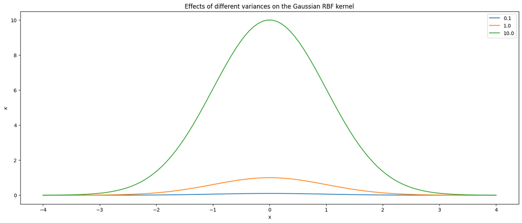

### Question

What is a condition of kernel function ?

### Answer

For any number $n \in \mathbb{N}$ and points $\{x_1, \dots, x_n\}$, kernel matrix $K$ defined as $$ K = \begin{bmatrix} k(x_1, x_1) & k(x_1, x_2) &\dots &k(x_1, x_n)\\ k(x_2, x_1) & k(x_2, x_2) &\dots &k(x_2, x_n)\\ \vdots & \vdots & \ddots & \vdots\\ k(x_n, x_1) & k(x_n, x_2) &\dots &k(x_n, x_n)\\ \end{bmatrix} $$ is a valid covariance matrix (a.k.a **positive-semidefinite** matrix)

A matrix $A$ is **Positive-semidefinite** if $v^\top A v \geq 0$ for all vector $v$

**Theorem**: Given two kernel functions $k_1, k_2$, $$k_+(x, x') = k_1(x, x') + k_2(x, x'), \quad k_\times(x, x') =k_1(x, x') k_2(x, x')$$ are both kernel function.

Proving it would be a good mathematical exercise! ($k_+$ is easy but $k_\times$ is tricky...)

### Exercise 2 and Question

How the shape of GP if we use following kernels $$k_+(x, x') = k_1(x, x') + k_2(x, x'), \quad k_\times(x, x') =k_1(x, x') k_2(x, x')$$

**Recall:** when kernel $k(x, x')$ is large for some $x, x'$, the values $f(x), f(x')$ should be similar

1. For $f \sim \mathcal{GP}(0, k_+)$, $f(x), f(x')$ are similar if $k_1(x, x')$ **or** $k_2(x, x')$ is large
2. For $f \sim \mathcal{GP}(0, k_\times)$, $f(x), f(x')$ are similar if $k_1(x, x')$ **and** $k_2(x, x')$ is large

*Theorem:* Let $f_1 \sim \mathcal{GP}(0, k_1), f_2 \sim \mathcal{GP}(0, k_2)$ Then,

1. $f_1 + f_2$ follows $\mathcal{GP}(0, k_1 + k_2)$
2. $f_1 f_2$ follows $\mathcal{GP}(0, k_1 k_2)$

(**Exercise**) Prove it! *Hint: Compute covarinace.*

Distinguish between: $$f \sim \mathcal{GP}(0, k_{rbf}(x, x') + \cos(2\pi (x -x'))), \quad f \sim \mathcal{GP}(0, k_{rbf}(x, x')\cos(2\pi(x -x'))$$

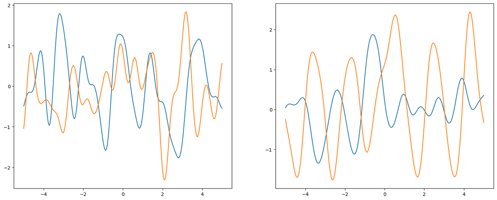

### Question

How to select kernels? (e.g. Matern kernel v.s Gaussian Kernel)

### Answer

- Reflect your prior knowledge on function
  - Function is periodic: Use cosine or periodic Mattern kernel
  - Function has linear trend: Use linear kernel
- Combine them adequately
- **Maximize marginal likelihood!**

**Useful facts** Let $k(x,y) = \phi(x)^\top\phi(y)$. All functions $f$ sampled from $f \sim \mathcal{GP}(0, k)$ can be written as

$$f(x) = w^\top \phi(x), \quad w \sim \mathcal{N}(0, I)$$

[**Exercise**] Prove it!

**Examples**

- Linear kernel $k(x,y) = x^\top y$:

$$f(x) = w^\top x, \quad w \sim \mathcal{N}(0, I)$$

- Cosine kernel $k(x,y) = \cos(x - y)$:

$$f(x) = w_1 \cos(x) + w_2\sin(x), w_1,w_2 \sim \mathcal{N}(0,1)$$

**Useful facts** Mattern Kernel $\nu$: $$k(x, x') = \frac{1}{\Gamma(\nu) 2^{\nu-1}} \left(\frac{\sqrt{2\nu}}{l} \|x-x'\|\right)^\nu K_\nu \left(\frac{\sqrt{2\nu}}{l} \|x-x'\|\right)$$

- "Mattern 3/2" means Mattern kernel with $\nu = 3/2$
- Exponetial kernel is Mattern kernel with $\nu = 1/2$
- Gaussian kernel is Mattern kernel with $\nu = \infty$
- **Larger $\nu$ means smoother function**

### Exercise 3

Can you identify the covariance function used to generate the following samples?

[figure not shown]

Options: *Periodic * Matern 5/2; Matern 3/2 + Bias; Matern 1/2 * RBF; Linear * Cosine; RBF; Exponential*

[figure not shown]

(a) RBF (b) Linear * Cosine (c) Matern 3/2 + Bias (d) Exponential (e) Matern 1/2 * RBF (f) Periodic * Matern 5/2

### Exercise 4

The initial fit would be:

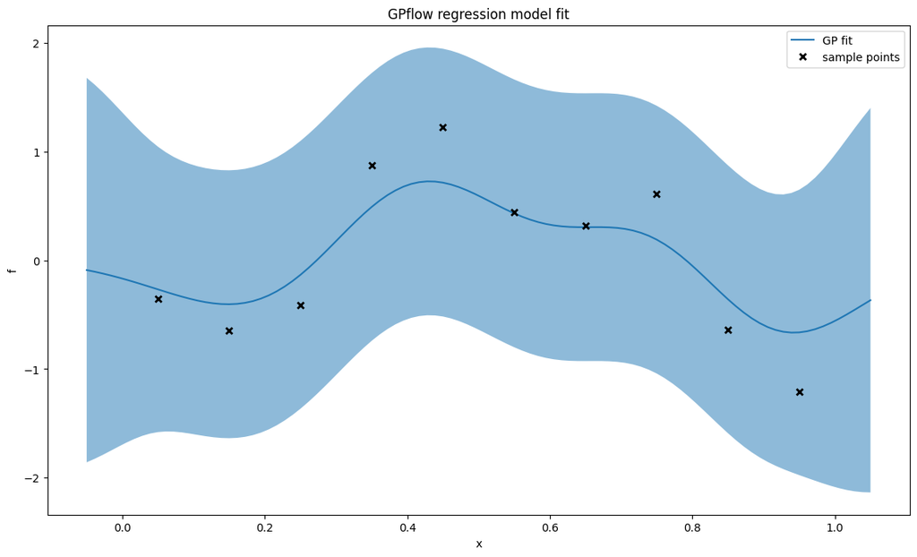

(a) What do you think of this initial fit? Does the prior given by the GP seem to be adapted?

It's clear that the observations are captured in the confidence interval, but the fit is not particularly good. The parameters used may not be the best they can be to minimise the loss of the fit.

(b) The parameters of the model can be edited much like those of the kernel. Change the values of the parameters to try and obtain a better fit of the GP. You can recalculate the updated mean and covariance after changing the values by calling `m.predict_noiseless` as above.

<gpflow.models.gpr.GPR object at 0x718f0d346c90>

| name | class | transform | prior | trainable | shape | dtype | value |
| --- | --- | --- | --- | --- | --- | --- | --- |
| GPR.kernel.variance | Parameter | Softplus |  | True | () | float64 | 1 |
| GPR.kernel.lengthscales | Parameter | Softplus |  | True | () | float64 | 0.1 |
| GPR.likelihood.variance | Parameter | Softplus + Shift |  | True | () | float64 | 0.01 |

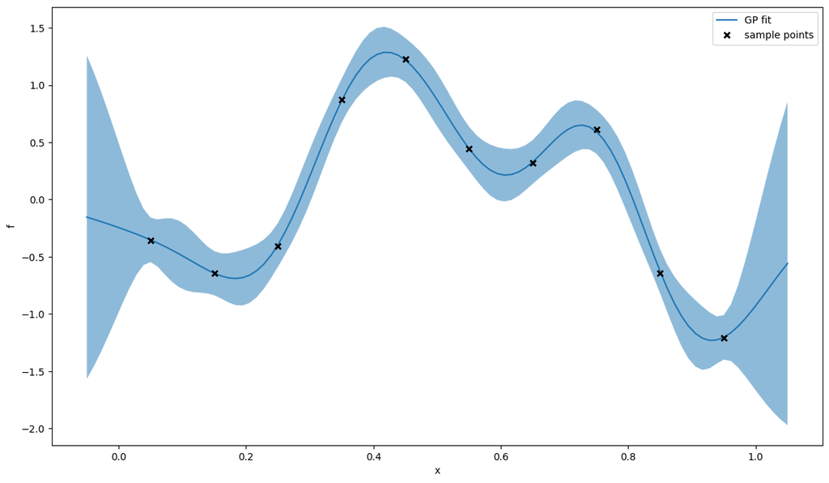

(c) Given that we can obtain the mean and covariance of the GP fit, we can also sample the GP posterior as a multivariate Gaussian process. This can be done as in Section 4, where we sampled the priors as defined by the kernels, i.e. with `np.random.multivariate_normal`. Obtain 10 samples from the GP posterior and plot them alongside the data. Try to simulate noisy measurements using `m.predict_y` (rather than `m.predict_f`).

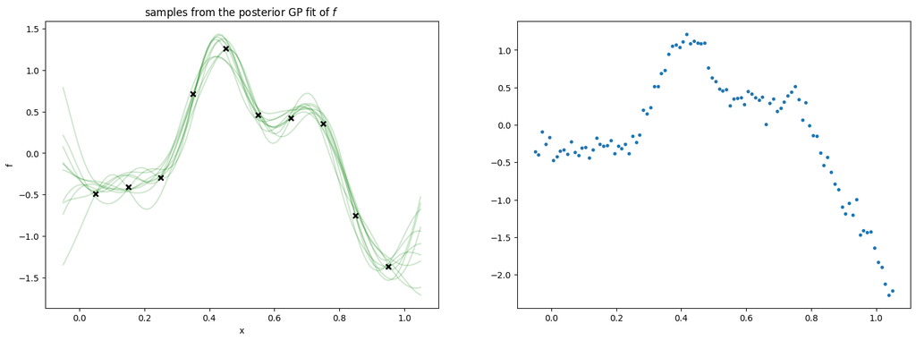

### Question

Do you manually tune them in reality?

### Answer

No! GPflow provides tools to tune them by maximizing marginal likelihood

```
o = gpflow.optimizers.Scipy()
o.minimize(m.training_loss, m.trainable_variables)
```

### Question

What is the difference between likelihood variance and kernel variance?

### Answer

kernel variance is the scalar $\sigma$ applied to RBF kernel: $$k_{\mathrm{rbf}} = {\color{red}{\sigma}} \exp\left(\|x-x'\|^2 / l\right)$$ which represents the **scale of the function**

likelihood variance is $\lambda$ that appears marginal likelihood of GP $$ \log p(y|x, \mathcal{GP}(0, k)) = \mathbf{y}^\top (K + {\color{red}{\lambda}} I)^{-1} \mathbf{y} - \frac12 \log \det(K + {\color{red}{\lambda}}I) - \frac{n}2 \log 2 \pi$$ which represents **the noise in data**

[**Exercise**] Derive marginal likelihood of GP

### Exercise 5 [Optional]

(a) Try predicting the outside of the data

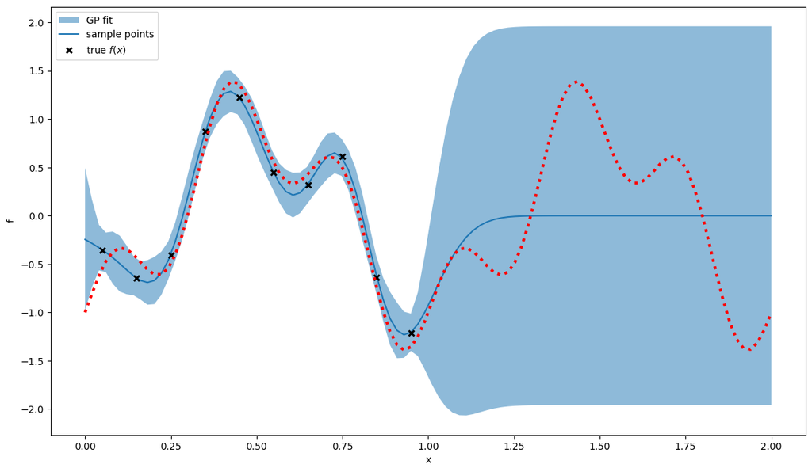

(b) Comment on the fit of the GP, and the uncertainty in regions where we have no observations. Is the GP still a good fit? How might we produce a better fit, for example, if we knew $f(x)$ had a periodic nature?

The prediction becomes useless in the areas where we are extrapolating, which makes some degree of sense. However, since the function is sinusoidal, we can see there is some periodicity that we may be able to exploit in our GP fit

### Exercise 6 [Optional]

(a) Create a `Linear` kernel with reasonable estimates of the parameters that represent the trend?

```
k_L = gpflow.kernels.Linear(variance=1.)
```

(b) How might we encode this trend in the mean estimate of the GP ?

Use a mapping function to represent the linear trend. We can hard code the parameters (gradient and intercept), or give them priors.

(c) Create a GP regression model using the kernels to fit the data. Comment on good is the fit and the predictive power of the model?

```
# Linear covariance function
m1 = gpflow.models.GPR(
    (X, Y),
    kernel=gpflow.kernels.Linear(variance=1.) + gpflow.kernels.Bias(360),
)

mean, Cov = predict_y(m1, Xnew)

plt.figure(figsize=(14,8))
plot_gp(Xnew, mean, Cov)
plt.plot(X, Y, ".b", Xtest, Ytest, ".r", alpha=0.4);
plt.legend(labels=["GP fit","training points", "test points"])
```

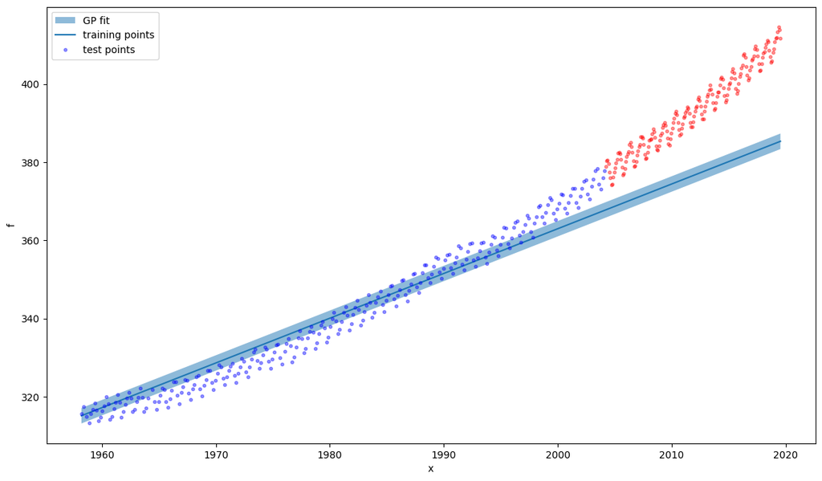

### Exercise 7

What improvements might be made to the GP model, for example in terms combinations of kernels and parameters, to get a better fit, especially for the prediction of our testing data?

- the number of optimisation restarts of the hyperparameters.
- add mean function of GP
- try different combination of kernels, reduce redundant kernel